# Bayesian Modeling Problem Set 4 & 5

## B. Posterior Predictive Penguins

Now that we’ve worked hard just to replicate the simple step of running a basic univariate linear regression in a Bayesian setting and conducting appropriate levels of model fitting (which have mostly told us, as we expect, that our random predictor does a very poor job at explaining the data, but that our model is now correctly specified and passes a simple posterior predictive check), we can continue with overfitting our regression!

1. To overfit our regression, we are going to start by producing not just 1 random predictor variable, but 30 random variables. You can do this all at once by producing a 30 x 30 matrix full of random normal values with a mean of 0 and sd of 1. Store this matrix as the object `predicts’.

```r
set.seed(2025)
predicts=matrix(rnorm(30*30,mean=0,sd=1),30,30)
```

2. So now we need to run 30 Bayesian models, each with increasing number of predictors. In Part A, we ran the first model, using 1 predictor. A second model would use 2 (random) predictors, a third model should use 3, etc., until our 30th model uses all 30 predictors! We are going to store the JAGS model output for each consecutive model into a `list()` which is a very useful structure in R to hold complex objects (such as fit models). Create an empty list called `penguin.mods`. You can fill the first element of your list with your previous model object with 1 random predictor.

```r
penguin.mods=list()
penguin.mods[[1]]=penguin.fit_pred
```

3. Rather than clutter our script copying and pasting the same code over and over, we’re going to use a function called `penguin.predict()` (Morgan has written for you!) that: (1) creates jags data, (2) defines the jags model, and (3) fits the model. All you need to provide it is your observed response (`penguin`), your matrix of random predictors (`predicts`), and the number of predictors you wish to use (`n.preds =`, from 2 to 30). The code below will load in the function into your R workspace. Test out the function for `n.preds=2`, saving the object into the second element of your storage list `penguin.mods`.

```r
source("https://dl.dropboxusercontent.com/scl/fi/0koun9pztocb4uh3vi9zm/function_PenguinPredict.R?rlkey=ap5crocc4ctyatearl4kvbqeh&")
penguin.mods[[2]]=penguin.predict(2,predicts,penguin)
```

4. The function `penguin.predict()` should work, but the JAGS model code will be a bit different from your part A. In order to easily accomodate up to 30 predictors, each model will save the slopes into a vector of betas called `b.preds`. When `n.preds=2`, then `b.preds` will have 2 columns; when `n.preds=20`, then `b.preds` will have 20 columns, etc. Use `MCMCsummary()` to explore the parameters `b0` and `b.preds` from the model you stored in B.3.

```r
summary=MCMCsummary(penguin.mods[[2]],params=c("b0","b.preds"))
print(summary)
```

```
##                 mean       sd      2.5%       50%      97.5% Rhat n.eff
## b0         555.73374 45.45994  465.9308 554.34416 641.937257    1  1086
## b.preds[1] -11.87188 46.79115 -107.5165 -11.40954  77.379829    1  1200
## b.preds[2] -85.20706 49.23299 -177.3596 -84.08607   8.908665    1  1263
```

```r
b.pred_2=MCMCchains(penguin.mods[[2]],params="b.preds")
ncol(b.pred_2)
```

```
## [1] 2
```

```r
#Indeed it contains 2 columns
```

5. Has the addition of a single random predictor (for a total of 2) helped our model predictions at all? Recreate your plot from A.7 but use the PPD (`penguin.pred`) from your model with 2 predictors. Add a title to your plot, “n.preds = 2”.

```r
ppd_mods=MCMCchains(penguin.mods[[2]],params="penguin.pred")
sim_mean_mods=apply(ppd_mods, 1, mean)
obs_mean_mods=mean(penguin)

hist(sim_mean_mods,breaks=20,main="n.pred=2",xlab="Simulated Means",ylab="Frequency")
abline(v=mean(obs_mean_mods),col="red",lwd=2,lty=2)
legend("topright",legend ="Observed mean",col="red",lty=2,lwd=2)
```

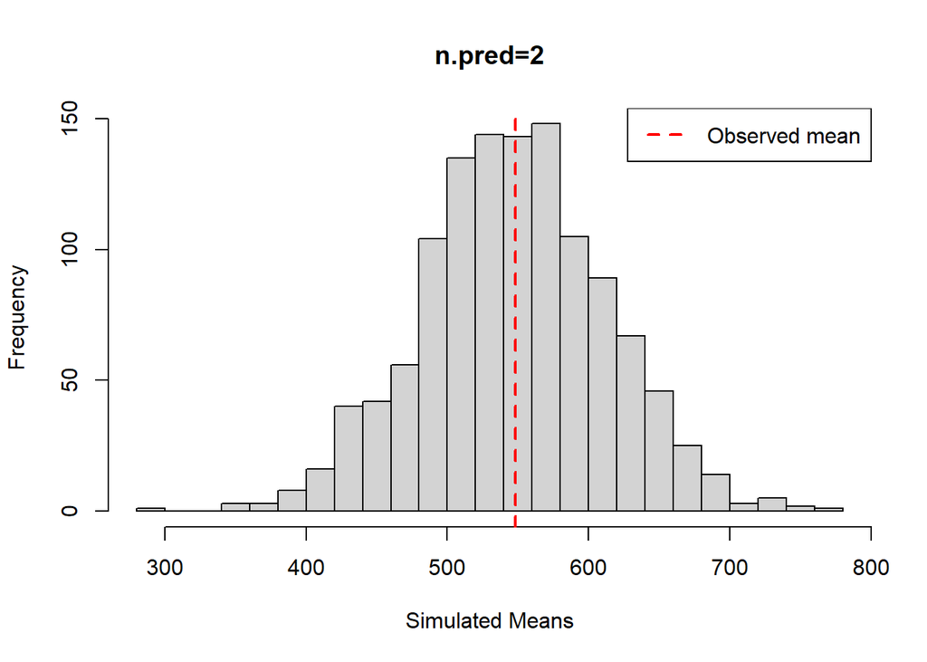

[figure not shown]

```r
p_value_mods=mean(sim_mean_mods>obs_mean_mods)
p_value_mods
```

```
## [1] 0.4891667
```